# Probabilidade (PPGECD000000001)

Programa de Pós-Graduação em Estatística e Ciência de Dados (PGECD)

Universidade Federal da Bahia (UFBA)

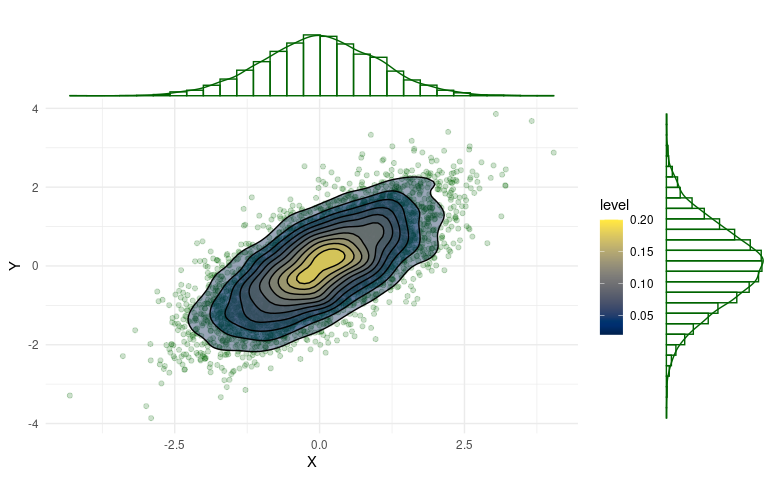

- **Professor:** Raydonal Ospina Martínez
- **Homepage do Curso:** https://raydonal.github.io/MProbPGECD/
- **Contato:** raydonal@castlab.org
- **Ementa do curso:** Experimento aleatório, espaço amostral, eventos e coleção de eventos, probabilidade, probabilidade condicional e independência, variável aleatória, funções de probabilidade, densidade e distribuição, vetores aleatórios, esperança, variância, momentos. Esperança de funções de vetores aleatório e propriedades. Distribuições condicionais e propriedades. Distribuições de funções aleatórias e de vetores aleatórios, modos de convergência e suas relações, função característica, leis dos grandes números, teorema central do limite. Experimentos aleatórios, espaço amostral, eventos. Geração de eventos a partir de operações elementares da teoria dos conjuntos. Limites superior e inferior. Axiomas de Kolmogorov. Propriedades das medidas de probabilidade. Probabilidade condicional. Independência. Lemas de Borel-Cantelli. Variáveis aleatórias contínuas e discretas. Função distribuição acumulada e suas propriedades Integral de Riemman Stieltjes. Esperança e variância de variáveis aleatórias e propriedades. Principais distribuições discretas e contínuas. Vetores aleatórios, função distribuição conjunta e função densidade conjunta de um vetor aleatório. Distribuições marginais. Distribuições mistas. Esperança de vetores aleatórios. Desigualdade de Cauchy-Schwarz. Matriz de covariância. Coeficiente de correlação e propriedades. Função característica e função geradora de momentos conjunta, cálculo de momentos conjuntos (momentos mistos). Exemplos de distribuições multivariadas. Distribuições multinomial e Normal multivariada. Propriedades da Normal multivariada. Distribuições condicionais e esperança condicional: Definições, existência, propriedades. Variância condicional. Função de Regressão. Fórmulas da variância total e da covariância total.
- **Local e horário da disciplina:** As aulas serão ministradas às terças e quintas feiras das 8:50 às 10:40 horas (TURMA T01) na sala 20 do IME (Instituto de Matemática e Estatística - Av. Milton Santos, s/n° Ondina, CEP: 40170-110).
- **Atenção aos estudantes:** Reunião virtual via google-meet ou reunião presencial com prévio agendamento. O local de atendimento presencial será em alguma sala disponível no Departamento de Estatística da UFBA.
- *Nota: O atendimento será realizado somente com agendamento prévio. Prezado(a) aluno(a), valorizo muito o meu tempo, assim como o seu. Para utilizarmos nosso tempo de forma eficiente, peço que envie suas dúvidas antecipadamente para que eu possa me preparar adequadamente. Por favor, traga também anotações e procedimentos já elaborados. A pontualidade é essencial e será muito apreciada.*
- **Metodologia:** Considerando o caráter teórico da disciplina, a metodologia de ensino e aprendizagem utilizará quadro e/ou slides para a apresentação do conteúdo em sala de aula. Será empregada uma plataforma virtual para disponibilizar materiais didáticos, incluindo artigos científicos. Além disso, serão implementadas aulas invertidas, com o envio de videoaulas relacionadas a temas especializados e específicos do assunto em estudo, bem como listas de exercícios.
- **Objetivos da disciplina:** Esta disciplina teórica e obrigatória tem como objetivo proporcionar uma base matemática e Estatística aos alunos de diferentes áreas do conhecimento que estejam interessados em probabilidade, visando à compreensão e aplicação de seus principais conceitos e métodos. Para esse fim, o curso é dividido em várias unidades nas quais são introduzidos resultados e teoremas centrais da probabilidade, bem como exemplos que motivam o estudo. Ferramentas computacionais (software) poderão apoiar o desenvolvimento de alguns temas do curso. O objetivo central da disciplina é estudar modelos de probabilidade de forma que permitam ao estudante formular, analisar e aplicar modelos probabilísticos. Além disso, busca-se proporcionar ao estudante a infraestrutura necessária para consolidar sua capacidade de pensar conceitualmente.

A avaliação tem como objetivo ajudar ao aluno a progredir nas suas aprendizagens e serve também para estabelecer os resultado dos conhecimentos e das competências adquiridas nos diferentes momentos do período acadêmico. A avaliação também contribui para a qualidade do sistema de ensino (REGPG Cap. VI, Art. 106 – UFBA, 2014). A avaliação consistirá de três provas (com conteúdo cumulativo) ao longo do curso. O grau atribuído ao aluno no final do curso será o da sua média global ponderada entre as notas das provas

### M = (0,35 * Prova 1)+(0,35 * Prova 2)+(0,3 * Prova 3)

| Avaliação | Porcentagem | Data da Prova (Tentativa) |
| --- | --- | --- |
| Prova 1 | 35% | 15/05/2025 |
| Prova 2 | 35% | A definir |
| Prova 3 | 30% | A definir |

A avaliação poderá ser revisitada em função do desempenho, assistência e participação na disciplina.

- **Nota:** Não haverá escalonamento de notas.

# Programa da disciplina (Tentativo)

| **Aula** | **Unidade Temática ou Conteúdo** | **Material** |
| --- | --- | --- |
| 1 | Revisão - conceitos básicos | [slides 1], [[videoaula]](https://youtube.com/playlist?list=PL5Dg8nFln2eVou0YbxuUiYWmjPuxTLAYe&si=q5Ym1M9YkVWOUiN1) |
| 2 | Experimentos aleatórios, espaço amostral, eventos. Coleção de eventos, funções indicadoras. | [[videoaula]](https://youtu.be/ez-wI3l720k?si=QLLbdLjucCK2L_d0) |
| 3 | Fundamentos e probabilidade, frequência relativa | [slides 2] |
| 4 | Axiomas de Kolmogorov | [[videoaula]](https://youtu.be/MotRLSAZ1wA?si=Q47dt0w5MfaDTmUC); [[videoaula]](https://youtu.be/rZLik7tsaw4?si=DLuSWNYdAs-nG4Dr) |
| 5 | Propriedades de uma medida de probabilidade | [slides 3] |
| 6 | Probabilidade condicional, independência. | [slides 4] |
| 7 | Variáveis aleatórias, função de distribuição acumulada e tipos de variáveis aleatórias | [slides 5] |
| 8 | Decomposição de variáveis aleatórias | [[videoaula]](https://youtu.be/WB5apGR07js?si=RahncTJwfqZanIAr) |
| 9 | Principais distribuições discretas (caso univariado). | [[videoaula]](https://youtu.be/r9M4NMSslG8?si=kX-xGBTMaWbdQPFo) |
| 10 | Principais distribuições continuas (caso univariado). | [[App]](https://davidbarke.shinyapps.io/Distributions/) |
| 11 | Vetores aleatórios - Distribuição de Probabilidade | [slides 6] |
| 12 | Prova I - (virtual) | Não haverá aula [[videoaula]](https://youtu.be/jb0eGzWv4xg?si=xXje-b5oOTmlHt1W) |
| 13 | Vetores aleatórios, função de distribuição acumulada conjunta de um vetor aleatório | Exemplos |
| 14 | Vetores aleatórios, funções de densidade e massa de probabilidade conjunta | [Lec. Medida Produto] |
| 15 | densidade condicional | Exemplos |
| 16 | Independencia de variáveis aleatórias | [[videoaula]](https://youtu.be/uwIv3TZhZtk?si=SFh7T0ltlHh5l09_) |
| 17 | Vetores aleatórios e função de distribuição conjunta de um vetor aleatório | [[videoaula]](https://youtu.be/GRbK-oV5Otk?si=-tAqFOPWsEjMI3JJ); [Lec - Funções] |
| 18 | Método do Jacobiano | [Lec - Jacobiano]; [[videoaula]](https://youtu.be/Lbct0bULtHU?si=qpHVW9Hspp6zQZIZ) |
| 19 | Prova II - (virtual) | Transformação de v.a. [[videoaula]](https://youtu.be/ypluLvdaniU?si=qyfPkmAMqkFBb8hG) |
| 20 | Esperança de variáveis discretas. Integral de Riemman Stieltjes e integral de Lebsgue-Stieltjes | [Lec - R-S]; [[App]](https://davidbarke.shinyapps.io/Distributions/) |
| 21 | Esperança de variáveis aleatórias, caso geral e propriedades | [Lec. Esperança] |
| 22 | Esperança de funções de vetores aleatórios, propriedades, matriz de variância e covariância, coeficiente de correlação, propriedades, desigualdade de Cauchy-Schwarz | [slides 7] |
| 23 | Correlação e desigualdades, valor esperado condicional | [slides 8] ; [Material resumo] |
| 24 | Sequencia de eventos | [slides 8] |
| 25 | Modos de convergências | [slides 9] |
| 26 | Funções característica | [slides 10] |
| 27 | Lei dos grandes numeros | [slides 11] |
| 28 | Teorema Central do Limite (Liapunov) - (Lindeberg - Feller) | [slides 12] |
| 29 | Prova III | Prova escrita |

#### Referências bibliográficas (Principal)

- James, B. (1981). Probabilidade: Um Curso em Nível Intermediário, IMPA. (Livro texto tentativo).
- Magalhães, M. N. (2004). Probabilidade e Variáveis Aleatórias. Ed. Universidade de São Paulo.
- Campos, M. A., Rêgo, L. C., & de Mendonça, A. F. (2017). Métodos probabilísticos e estatísticos com aplicações em engenharias e ciências exatas. Grupo Gen-LTC.
- Feller, W. (1968) An introduction to probability theory and its applications, vol. I, 3a edição. Wiley.
- DasGupta, A. (2011). Probability for statistics and machine learning: fundamentals and advanced topics (p. 566). New York: Springer.
- Aggarwal, C. C. (2024). Probability and Statistics for Machine Learning: A Textbook. Springer Nature.
- Murphy, K. P. (2023). Probabilistic machine learning: Advanced topics. MIT press.
- Fine, T. L. (2006). Probability and probalistic reasoning for electrical engineering. Pearson Prentice Hall .
- [MIRANDA, D.; GRISI, R.](https://danielmiranda.prof.ufabc.edu.br/prob/probabilidade.pdf) Pobabilidade. São Paulo: UFABC, 2022.

#### Referências bibliográficas (Complementar)

- Dantas, C. A. B. (1997) Probabilidade: Um Curso Introdutório. Ed. USP, São Paulo.
- Davenport Jr., W. (1970) Probability and Random Processes. McGraw-Hill.
- Mood, A. Graybill, F. e Boes D. (1985). Introduction to the Theory of Statistics . McGraw-Hill.
- Papoulis, A. (1991) Probability, Random Variables, and Stochastic Processes. McGraw-Hill.
- Pitman, J. (1993) Probability. Springer. [Biblioteca CCEN, (519.2 P685p)].
- Ross, S. M. (2001) A First Course in Probability. 3a edição, McMillan Publishing.
- Ross, S. M. (1997) Introduction to Probability Models. McGraw-Hill.
- Trivedi, K. (2002) Probability and statistics with reliability, queuing and computer science applications, 2a edição. John Wiley & Sons.

#### Software (Interessados em implementar seus conhecimentos)

1. [An Introduction to R](http://cran.r-project.org)
2. [SAS - Acadêmico](https://www.sas.com/pt_br/learn/academic-programs/software.html)
3. Rstudio
4. TeXnicCenter
5. [Python](http://www.python.org/)
6. [Julia](https://julialang.org/)
7. [ChatGPT e outros](https://chatgpt.com/g/g-cHGvFfMYD-probability-prover)

## Para refletir

##### Sobrea as aulas

*São reuniões cientificas e profissionais onde são discutidos temas de relevância para a formação pessoal, social e profissional. Portanto é esperado que o aluno chegue sem atraso, não entre na sala abruptamente, não sai da sala durante a discussão, respeite as intervenções do professor e/ou colega(s), não fume (Lei Federal), não use o celular e não promova a destruição de bens públicos, entre outros.*

##### Sobre honestidade acadêmica

*Honestidade e confiança são importantes para todos nós como indivíduos. Neste sentido, os membros da comunidade acadêmica tanto como professores e alunos têm a responsabilidade de manter e promover os princípios da verdade e honestidade acadêmica. Assim, a honestidade acadêmica pressupõe que todos os trabalhos, provas e testes sejam frutos do trabalho individual do aluno salvo os casos onde o professor tenha dado permissão expressa e instruções para a realização de atividades em grupo.*

##### Sobre profissionalismo

*Aluno, você já não é mais criança ou adolescente, mas adulto. Durante seu tempo na universidade, você formará quem você será pelas próximas décadas. O mercado de trabalho quer apenas os melhores e os mais profissionais. Haja desde já como o profissional que você deseja ser. (Fonte: Política do Curso e Etiqueta em Sala de Aula, Professor Dr. Renato J. Cintra).*

##### Sobre tratamento pessoal

*Lembrem que nós somos respeitados e tratados da mesma forma em que tratamos as demais pessoas. Ao se dirigir a professores e/ou colegas, faça-o respeitosamente.*

##### Sobre o aluno

*Finalmente quero lembrá-lo que você constrói seu conhecimento e desenvolve sua capacidade de aprender e criar. Seu instrutor está aqui para orientá-lo. Trabalhe, pesquise, seja crítico construtivo, crie, se dedique, se esforce e não desista, se pensar em desistir se esforce mais. Não se preocupe e melhor se ocupe. Você está aqui porque tem condições de vencer.*

### Material de apoio

O material de apoio será distribuído ao longo do curso. Esse material pode incluir, livros, slides de aula, scripts para reprodução, artigos científicos e artigos de divulgação, entre outros.

### Atividades

- Lista de exercícios -

- Introdução à Probabilidade
  - Exercícios da seção 1.2 do livro do Marcos Magalhães.
  - Exercícios 1,2,3 da seção 1.3 do livro do Marcos Magalhães.
  - Exercícios 1,2,4,5,7,8,9,13,14,15,20,21,26,28,33,34,42,44,47,53,56,61,86 da seção 1.4 do livro do Marcos Magalhães.
  - Exercícios 1,2,3,5,6,9,10,11,12,13,14,15 da seção 1.4 do livro do Barry James.
- Probabilidade Condicional e Independência
  - Exercícios 4,5,6,7 da seção 1.3 do livro do Marcos Magalhães.
  - Exercícios 23,24,25,27,35,36,37,38,39,40,43,45,46,48,49,50,57,58,59,64,65,71,72,84,85,96,100,101 da seção 1.4 do livro do Marcos Magalhães.
  - Exercícios 16,17,18,19,20,21,22 da seção 1.4 do livro do Barry James.
- Variáveis Aleatórias
  - Exercícios 1,2,3,4,5,6(a)(b),7,8,9(a)(b),10 da seção 2.2 do livro do Marcos Magalhães.
  - Exercícios 1,2,3,4,5,6,9,10 da seção 2.3 do livro do Marcos Magalhães.
  - Exercícios 1,2(a)(c),3,4,5,6,7,8,9,10 da seção 2.4 do livro do Marcos Magalhães.
  - Exercícios 3,4,5,6,7,8,9,11,12,13,14,15,16,17,18,19,20(d),22(b)(d)(e),24,26,28,33,35(a)(c),36,37,39(b),41,42,43,44 da seção 2.5 do livro do Marcos Magalhães.
  - Exercícios4,9,10,13,14,17,18,20,23,25,27,31,32,33,34,35,36,37,41,42,43,44,45,46,47,48,49,50,51, 52,53,56,57,60,61 da seção 2.9 do livro do Barry James.
  - Exercícios 1,2,10 da seção 3.2 do livro do Marcos Magalhães.
  - Exercícios 1,2,4,5,6,9,10 da seção 3.3 do livro do Marcos Magalhães.
  - Exercícios 1,4,5,6,7,8,14,15,20,22,24,26,30,34,35 da seção 3.4 do livro do Marcos Magalhães.
- Esperança e Momentos de Variáveis Aleatórias
  - Exercícios 2,3,4,5,8,9,10 da seção 4.2 do livro do Marcos Magalhães.
  - Exercícios 1,6 da seção 4.3 do livro do Marcos Magalhães.
  - Exercícios 1,2,3,4,5,6,7,8,9,10 da seção 4.4 do livro do Marcos Magalhães.
  - Exercícios 1,5,6,7,8,9,10,11,12,13,14,15,16,17,20,24,26,29,34 da seção 4.5 do livro do Marcos Magalhães.
  - Exercícios 1 até 10 da seção 5.2 do livro do Marcos Magalhães.
  - Exercícios 1,2,3,4,5,6,7,8,9,10,11,12,13,14,15,16,25 da seção 5.6 do livro do Marcos Magalhães.
  - Exercícios 1 até 24, 27,28,31,32,33,35,36 da seção 3.8 do livro do Barry James.
- Distribuição e Esperança Condicional
  - Exercícios 1,2,4,9,10,14,15,16,17,18,19,21,23,26,27,28,35,36,38,39,41 da seção 4.6 do livro do Barry James.
- Convergência Estocástica
  - Exercícios 1, 3, 4, 5, 6, 7, 8, 9, 10, 11, 12, 13 da página 218 do livro do Barry James.
  - Exercícios 1,2,3,4,7,9,10,11,12 da página 322 do livro do Marcos Magalhães.
  - Exercícios 1, 2, 4, 7, 11, 13, 14, 15, 18, 21, 24 da seção 6.5 do livro do Marcos Magalhaes.
- Funções Características
  - Exercícios 1, 2, 4, 5, 6, 7, 8, 9, 13, 14, 17, 18, 19, 20, 21, 22, 23, 24, 27 da página 257 do livro do Barry James.
  - Exercícios da seção 5.5 da página 289 do livro do Marcos Magalhães.
  - Exercícios 53, 54, 55, 56, 59, 60, 62, 63 da página 296 do livro do Marcos Magalhães.
  - Exercícios 5, 6, 8 da página 322 do livro do Marcos Magalhães.
  - Exercícios 5,6,19,34,35,41 da seção 6.5 do livro do Marcos Magalhães.
- Lei dos Grandes Números
  - Exercícios 2, 14, 15, 16, 18, 19, 20, 21, 24, 25 da página 218 do livro do Barry James.
  - Exercícios 2,3,4,5,6,7,8,9,10,11,12 da página 336 do livro do Marcos Magalhães.
  - Exercícios 10, 22,30,45,55,57,58,59 da seção 6.5 do livro do Marcos Magalhães.
- Teorema Central do Limite
  - Exercícios 2, 3, 4,5, 7, 8, 9,11 da página 285 do livro do Barry James.
  - Exercícios 1,2,4,5,6,7,8 da página 349 do livro do Marcos Magalhães.
  - Exercícios 38,39,52, 57, 58,61 da seção 6.5 do livro do Marcos Magalhães.

### Provas

- [ Prova I ] - [Notas]
- [ Prova II ] - [Notas]
- [ Prova III ] - [Notas]
- [ Nota Final ]

###### Content Copyright © 2025 Raydonal Ospina Martínez. All Rights Reserved.